# Aides Drug

Moises Sales!

11/16/2019

# Introduction

# Methods

In this survery our two variables will be categorical vs categorical resulting in us using a barchart for our graphical method, a cross tabulation for our numerical results and taking a chisqtest for our inferential results. All questions and variables will be tested using this same method over the five questions throughout this survey being asked about the following: Total Population,Females,Males,DrugUsers, and LGBTQ.

## Q1: Does the vaccine have results on the Total Population for the survey?

$H_0$: The vaccine has no effect on whether one contracts aids or not.

$H_A$: The vaccine affects whether one contracts aids or not.

## Q2: Does the vaccine have results on just Females in the survey?

$H_0$: The vaccine has no effect on whether females contract aids or not

$H_A$: The vaccine affects whether females contract aids or not.

## Q3: Does the vaccine have results on just Males in the survey?

$H_0$: The vaccine has no effect on whether males contract aids or not.

$H_A$: The vaccine affects whether males contract aids or not.

## Q4: Does the vaccine have results on Drug Users in the survey?

$H_0$: The vaccine has no effect on whether drug users contract aids or not.

$H_A$: The vaccine affects whether drug users contract aids or not.

# Results

## Descriptive Results

### Graphical Descriptive Results

## Q1: Total Population

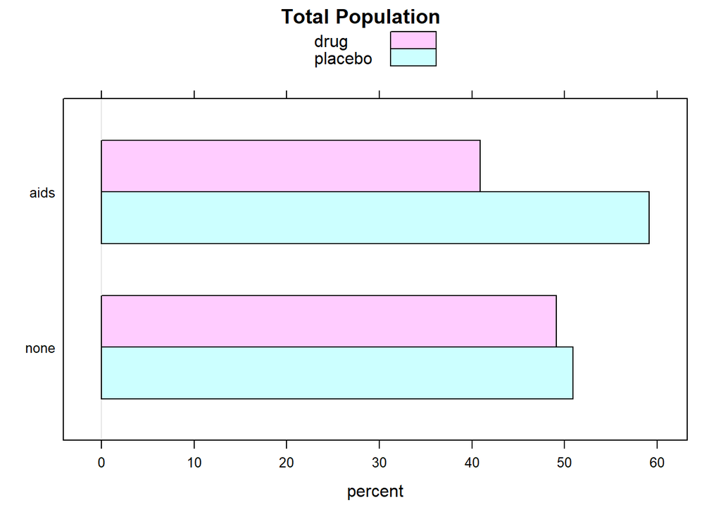

```r
barchartGC(~infected+treatment, type = "percent",main = "Total Population", horizontal = TRUE, data = filter(avast))
```

When looking at the total population within the survey there is a clear difference in percentages amongst the aids group that was affected by the vaccine to the placebo group. It appears as though a little over 40% of those affected by aids were given the vaccine while 60% responded to being affected who took the placebo.

## Q2: Females

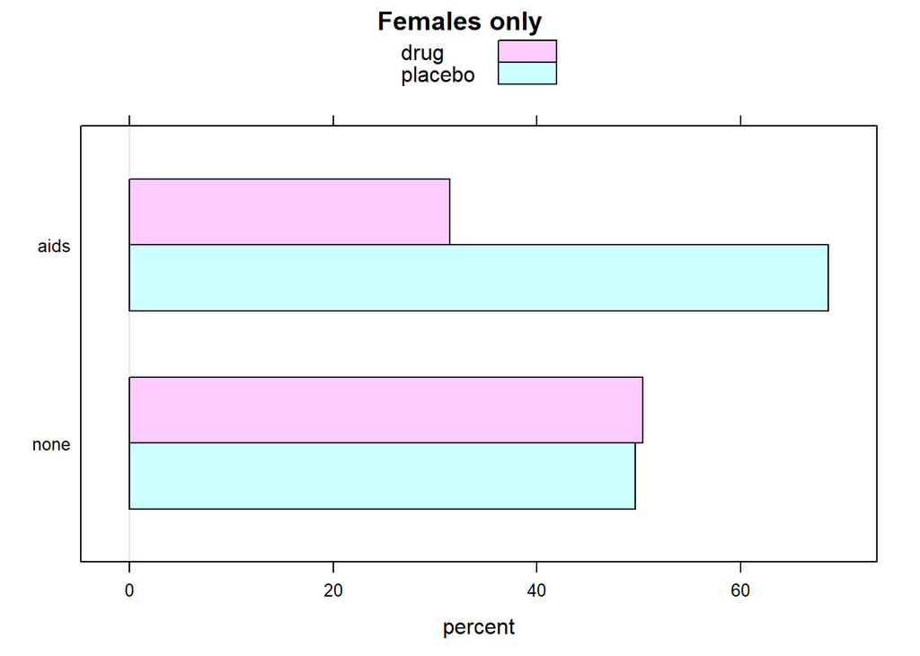

```r
barchartGC(~infected+treatment, type = "percent", main = "Females only", horizontal = TRUE, data = filter(avast, sex== "gal"))
```

The female only population in the survey appears to show a large difference within the percentages of the aids affected group. The female aids group shows that around 30% of the females who were given the drug were still affected by aids while around 70% of females in the aids group still responded to being affected by aids when given the placebo.

## Q3: Males

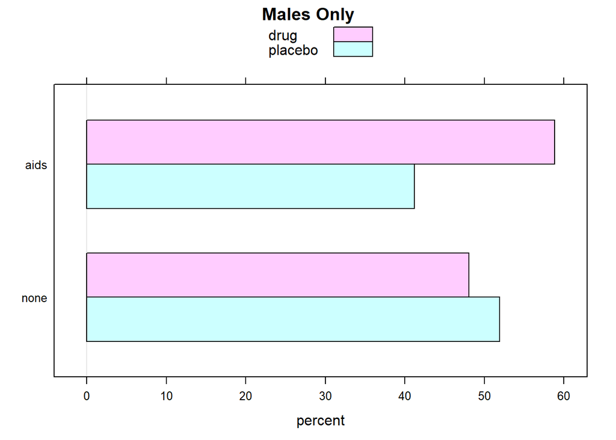

```r
barchartGC(~infected+treatment, type = "percent", main = "Males Only", horizontal = TRUE, data = filter(avast, sex=="guy"))
```

The male population appears to show that the aids group given the drug has a higher percentage than the placebo group in the aids affected group. This difference appears to be a 20% difference towards the drug group being a higher percentage.

## Q4: DrugUsers

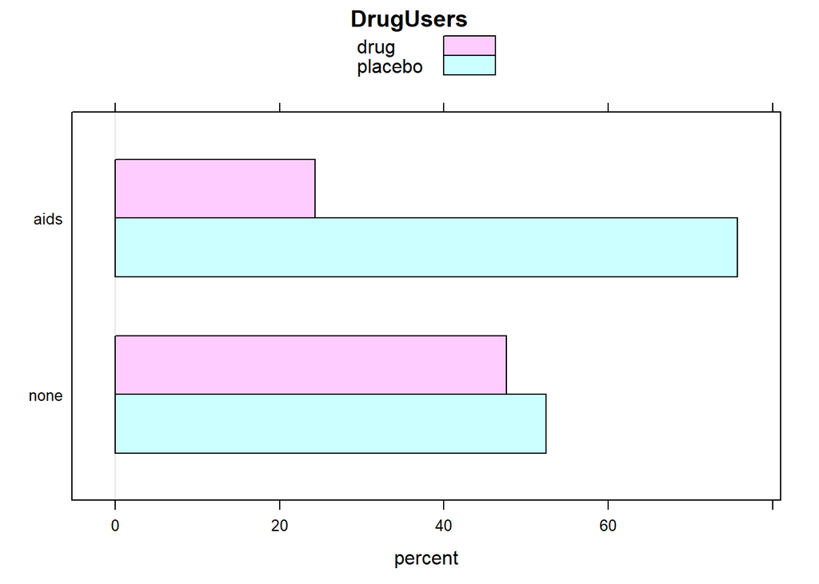

```r
barchartGC(~infected+treatment, type = "percent", main = "DrugUsers", horizontal = TRUE, data = filter(avast, DrugUser=="yes"))
```

The population of Drug Users within the survey shows that amongst the aids group those who were given the vaccine show a much lower percentage of being affected by aids than those in the same aids group who were given the placebo. The difference appears to be almost 3 times as many in the placebo compared to the the drug group for the aids affected group of drug users.

## Q5: LGBTQ

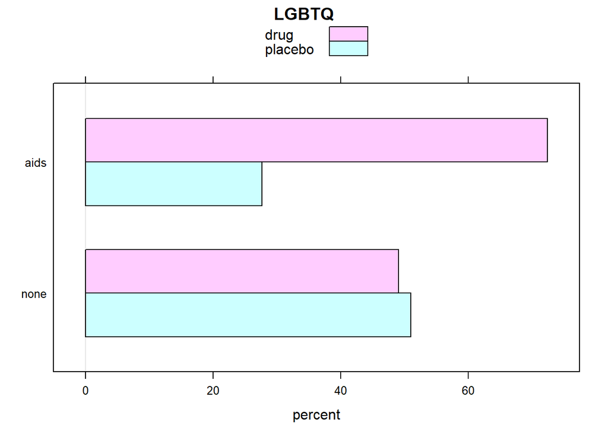

```r
barchartGC(~infected+treatment, type = "percent", main = "LGBTQ", horizontal = TRUE, data= filter(avast,LGBTQ=="gay"))
```

The population for LGBTQ within the survey show a large percentage of those still affected by aids even when taking the drug. In the aids group the drug percentage appears to be almost 3 times as much as that of the aids affected group that was given the placebo. This could potentially show that taking the drug could cause one to be more likely at risk of contracting aids amongst the LGBTQ population.

### Numerical Descriptive Results

## Q1: Total Population

```r
tab1 = xtabs(~infected+treatment, data = filter(avast))
rowPerc(tab1)
```

```
##         treatment
## infected   drug placebo  Total
##     aids  40.87   59.13 100.00
##     none  49.10   50.90 100.00
```

the Numerical results show that within the none group for the total population of those not affected by aids, show that there is no difference between taking the actual drug or placebo. However when looking at the treatment group for those affected by aids that did take the drug, there appears to be arounda 19% difference amongst those who took the treatment drug compared to those who took the placebo who were at around a 59%.

## Q2: Females

```r
tab2 = xtabs(~infected+treatment, data = filter(avast,sex=="gal"))
rowPerc(tab2)
```

```
##         treatment
## infected   drug placebo  Total
##     aids  31.42   68.58 100.00
##     none  50.38   49.62 100.00
```

The female only population appears to show that the drug cut the percentage of those affected by aids in half. The aids group for females showed at 31% of those still affected who took the vaccine while 68% still showed to be affected who were given the placebo. With this the treatment appears to affect the aids group if given the vaccine.

## Q3: Males

```r
tab3 = xtabs(~infected+treatment, data = filter(avast,sex=="guy"))
rowPerc(tab3)
```

```
##         treatment
## infected   drug placebo  Total
##     aids  58.82   41.18 100.00
##     none  48.06   51.94 100.00
```

The male only population appears to show that the aids group has roughly a 17% difference in between the drug given group and the aids group that was given the placebo. This difference appears to show significance that the drug seems to have some affect on contracting aids in the drug group.

## Q4: DrugUsers

```r
tab4 = xtabs(~infected+treatment, data = filter(avast,DrugUser=="yes"))
rowPerc(tab4)
```

```
##         treatment
## infected   drug placebo  Total
##     aids  24.29   75.71 100.00
##     none  47.59   52.41 100.00
```

The population of Drug Users appears to show that the group who were given the drug treatment amongst the aids group are at 24% which is 1/3 of the total of aids infected from the placebo group. This appears to support some idea that potentially taking the treatment gives a chance of preventing aids.

## Q5: LGBTQ

```r
tab5 = xtabs(~infected+treatment, data = filter(avast,LGBTQ=="gay"))
rowPerc(tab5)
```

```
##         treatment
## infected   drug placebo  Total
##     aids  72.38   27.62 100.00
##     none  49.05   50.95 100.00
```

The population of LGBTQ appears to show that the drug group has almost a 3 times larger affected rate than that of the placebo group. The aids infected who were given the drug appear to show a 72% infected rate while the placebo group show a much smaller 27% of being infected by aids.

## Q1: Total Population

```r
chisqtestGC(tab1)
```

```
## Pearson's Chi-squared test with Yates' continuity correction
##
## Observed Counts:
##         treatment
## infected  drug placebo
##     aids   423     612
##     none 10168   10540
##
## Counts Expected by Null:
##         treatment
## infected     drug  placebo
##     aids   504.15   530.85
##     none 10086.85 10621.15
##
## Contributions to the chi-square statistic:
##         treatment
## infected  drug placebo
##     aids 13.06   12.40
##     none  0.65    0.62
##
##
## Chi-Square Statistic = 26.4104
## Degrees of Freedom of the table = 1
## P-Value = 0
```

For our total population we end up with a P-value of 0 < 0.05 so we reject the null hypothesis that “$H_0$: The vaccine has no effect on whether one contracts aids or not.”. Thus we can conclude that the vaccine does affect the total population within this survey. When looking at our graphical results for our barchart, the treatment group for aids appears to be a lower percentile compared to that of the placebo group. This is further proved when looking at the numerical results as those affected by aids who took the treatment showed a 19% difference due to taking the vaccine compared to the same aids group that was administered the placebo. Due to these factors the overalll total population does indeed show that there is some affect to the vaccine on individuals affected by aids.

## Q2: Females

```r
chisqtestGC(tab2)
```

```
## Pearson's Chi-squared test with Yates' continuity correction
##
## Observed Counts:
##         treatment
## infected drug placebo
##     aids  213     465
##     none 4684    4613
##
## Counts Expected by Null:
##         treatment
## infected    drug placebo
##     aids  332.85  345.15
##     none 4564.15 4732.85
##
## Contributions to the chi-square statistic:
##         treatment
## infected  drug placebo
##     aids 43.15   41.62
##     none  3.15    3.03
##
##
## Chi-Square Statistic = 90.1943
## Degrees of Freedom of the table = 1
## P-Value = 0
```

For our female only group we end up with a P-value of 0 < 0.05 so we reject the null hypothesis that “$H_0$: The vaccine has no effect on whether females contract aids or not”. Thus we can conclude that the vaccine affects whether or not females contract aids or not. In our barchart there appears to be a large difference in the treatment aids group as those administered the treatment drug appear at less than half the size of those given the placebo. This is further supported when looking at the overwhelming 30%+ difference in our numerical results comparing the aids group given the drug at 31% while the aids placebo group at 68% still showed results of being affected by aids. This shows that there is some relationship to females contracting aids whether they take the drug or not.

## Q3: Males

```r
chisqtestGC(tab3)
```

```
## Pearson's Chi-squared test with Yates' continuity correction
##
## Observed Counts:
##         treatment
## infected drug placebo
##     aids  210     147
##     none 5484    5927
##
## Counts Expected by Null:
##         treatment
## infected    drug placebo
##     aids  172.74  184.26
##     none 5521.26 5889.74
##
## Contributions to the chi-square statistic:
##         treatment
## infected drug placebo
##     aids 8.04    7.54
##     none 0.25    0.24
##
##
## Chi-Square Statistic = 15.6339
## Degrees of Freedom of the table = 1
## P-Value = 1e-04
```

## Q4: DrugUsers

```r
chisqtestGC(tab4)
```

```
## Pearson's Chi-squared test with Yates' continuity correction
##
## Observed Counts:
##         treatment
## infected drug placebo
##     aids   34     106
##     none 1143    1259
##
## Counts Expected by Null:
##         treatment
## infected    drug placebo
##     aids   64.82   75.18
##     none 1112.18 1289.82
##
## Contributions to the chi-square statistic:
##         treatment
## infected  drug placebo
##     aids 14.66   12.64
##     none  0.85    0.74
##
##
## Chi-Square Statistic = 27.955
## Degrees of Freedom of the table = 1
## P-Value = 0
```

For our population of Drug Users in the survey, there ends up being a P-value of 0 < 0.05 so we reject the null hypothesis that “$H_0$: The vaccine has no effect on whether drug users contract aids or not.”. Thus we can conclude that the vaccine affects Drug Users on whether or not they contract aids. In the barchart for the graphical descriptive results, the data shows that there is a large difference among the drug and placebo affecting the aids group. The drug group appears to be a much smaller percentage than that of the placebo group showing that potentially the vaccine is working in preventing aids. This is further supported when looking at the aids infected group that the ones given the drug appeared to show a 24% of contracting aids while the placebo group showed a tremendous 75% of contracting aids. This supports that there is a affect on Drug Users on whether or not they contract aids for taking the drug or not.

## Q5: LGBTQ

```r
chisqtestGC(tab5)
```

```
## Pearson's Chi-squared test with Yates' continuity correction
##
## Observed Counts:
##         treatment
## infected drug placebo
##     aids   76      29
##     none 1007    1046
##
## Counts Expected by Null:
##         treatment
## infected    drug placebo
##     aids   52.69   52.31
##     none 1030.31 1022.69
##
## Contributions to the chi-square statistic:
##         treatment
## infected  drug placebo
##     aids 10.31   10.38
##     none  0.53    0.53
##
##
## Chi-Square Statistic = 20.8264
## Degrees of Freedom of the table = 1
## P-Value = 0
```

# Discussion and Conclusion

Within the survey it appears that the drug has different effects amongst the groups in our survey, however the drug does show that it does affect every group within the survey. Amongst our total population, females and drug users it appears that the drug does help prevent these populations from contracting aids. On the other hand it appears that the drug makes males and LGBTQ more likely to contract aids if they are given the drug. This relationship of showing a higher rate of contracting aids amongst males and LGBTQ suprisingly still does not outweigh the prevention amongst the total population and females who are also involved within the drug users population. Throug the total data shown it can be infered that for the most part the drug does help treat those infected with aids.